# Midterm Project

Anisha Shrestha

11/09/2019

##### Task 1: You will write a final data set as a csv file to the data folder. Name this file midterm-data-your_github_username.csv. The number of rows should be the same as the number of rows in the GTD data set.

> All the library used in the analysis

```r
options(warn = -1)
# to suppress all the warnings in the output
library(tidyverse)
library(plyr)  # If I will not use plyr then I am getting Error: Column `county` must be length 1 (the group size), not 30089
require(data.table)
library(usmap)
library(ggmap)
library(lubridate)
```

```r
library(ggrepel)
library(mapdata)
library(mapproj)
```

> Using Glimpse() function helps to have a look over all the datasets.

```r
GTD <- read_csv("data/GTD.csv")
  glimpse(GTD)
```

```
## Observations: 146
## Variables: 38
## $ iyear            <dbl> 2013, 2013, 2013, 2013, 2013, 2013, 2013, 2013,…
## $ imonth           <dbl> 1, 2, 2, 4, 4, 4, 4, 4, 4, 4, 5, 5, 5, 7, 8, 8,…
## $ iday             <dbl> 17, 7, 25, 15, 15, 16, 17, 18, 18, 19, 20, 20, …
## $ provstate        <chr> "Washington", "California", "Washington", "Mass…
## $ city             <chr> "Tacoma", "Corona", "Seattle", "Boston", "Bosto…
## $ latitude         <dbl> 47.25288, 33.87529, 47.59320, 42.35027, 42.3502…
## $ longitude        <dbl> -122.44429, -117.56644, -122.30057, -71.08098, …
## $ vicinity         <dbl> 0, 0, 0, 0, 0, 0, 0, 0, 0, 0, 0, 0, 0, 0, 0, 0,…
## $ summary          <chr> "01/17/2013: An explosive device detonated outs…
## $ doubtterr        <dbl> 0, 1, 0, 0, 0, 1, 1, 0, 0, 0, 1, 1, 1, 0, 0, 0,…
## $ multiple         <dbl> 0, 0, 0, 1, 1, 0, 0, 0, 0, 0, 1, 1, 1, 0, 0, 0,…
## $ success          <dbl> 1, 1, 1, 1, 1, 1, 1, 1, 0, 1, 0, 0, 0, 1, 1, 1,…
## $ suicide          <dbl> 0, 0, 0, 0, 0, 0, 0, 0, 0, 0, 0, 0, 0, 0, 0, 0,…
```

[output cut: 25 more lines]

> Getting state name from provstate. Placing DC in the state name `District Of Columbia`. Putting manually state name `DC` for District Of Columbia.

```r
mutate(GTD,state=state.abb[match(GTD$provstate,state.name)]) %>%
mutate(state = replace_na(state, 'DC')) -> GTD_dat
```

> Removing `NA` values from county/city Recoding ``city` name based on the GTD city values and drop NA values form the dataframe. From the repeated count choosing first observation (norepeat) Then Left merge : `gtd_merge`

```r
county_city <- read_csv("data/county_city.csv")
```

```r
county_city$city <- recode(county_city$city,
                          'New York'='New York City',
                          'Saint Cloud'='St. Cloud',
                          'Saint Louis'='St. Louis',
                          'Inglewood'='Ingelwood',
                          'Mc Cook'='McCook',
                          'Tyngsboro'='Tyngsborough')

county_city %>%
drop_na() -> county_all


county_all %>%
group_by(city, state) %>%
filter(row_number()==1) ->new_county
new_county %>%
mutate(county= str_replace_all(new_county$county," ", "")) -> dat_county


left_join(GTD_dat, dat_county, by = c('city','state'))->gtd_merge_data
gtd_merge_data%>%
distinct(iday, imonth,iyear,city,targtype1, target1, latitude, longitude, vicinity,summary, doubtterr, multiple, success, suicide, attacktype1, attacktype1_txt, targtype1_txt, targsubtype1, targsubtype1_txt, corp1, gname, individual, nperps, claimed, weapsubtype1,nkill, nwound,property,propextent, propextent_txt ,county, state, .keep_all = TRUE)-> gtd_merge
```

> Filtering datasets that has `City` in it as we are trying to combine county and state Changing the column name. `Area_Name` to `county` and `State` to `state` Filtering all the values that has `county` word in it from the column name `county` There are many typos in the values comparing with GTD data, we recode those county values Removing spaces from the county name and making one word just like above inorder to match for merge Left Merge data based on `county` and `state` .

```r
poverty <- read_csv("data/poverty.csv")
Filter_city1<-poverty[-(grep("City", poverty$Area_Name)),]
setnames(Filter_city1, old=c("Area_Name"), new=c("county"))
setnames(Filter_city1, old=c("State"), new=c("state"))
Filter_city1$county<- str_remove_all(Filter_city1$county, "County")

Filter_city1$county <- recode(Filter_city1$county,
                        'St. Louis '='Saint Louis City',
                        'Lafayette Parish'= 'Lafayette',
                        'East Baton Rouge Parish'='EastBatonRouge',
                        'St. Lucie '='Saint Lucie',
                        'Roanoke '='Roanoke City',
                        'Falls Church city'= 'Falls Church City',
                        'McLennan '='Mclennan',
                        'Orleans Parish'= 'Orleans',
                        'District of Columbia'= 'District Of Columbia'
                      )


new_poverty<- Filter_city1 %>%
mutate(county= str_replace_all(county," ", ""))

left_join(gtd_merge, new_poverty, by = c('county','state')) -> gtd_merge_county
gtd_merge_county%>%
  distinct(iday, imonth,iyear,city,targtype1, target1, latitude, longitude, vicinity,summary, doubtterr, multiple, success, suicide, attacktype1, attacktype1_txt, targtype1_txt, targsubtype1, targsubtype1_txt, corp1, gname, individual, nperps, claimed, weapsubtype1,nkill, nwound,property,propextent, propextent_txt ,county, state, .keep_all = TRUE) ->final_gtd_county_povert_merge
```

> Getting all state abb from the data population column name `STNAME`. Replacing `DC` in the place of STNAME i.e `District Of Columbia` and Filtering any values ending with (balance). Correcting typos in the observation values in order to match with GTD datasets. Removing all the words ending like `township`,`city`,`City`,`Town`,`village`,`borough`,`County`. Replacing the values in the data. Some values are different compared from GTD datasets. Column name: `provstate` and changing NAME to city. Final Merge data from all above is `finalmerge`

```r
population <- read_csv("data/population.csv")
population %>%
mutate(population,state=state.abb[match(population$STNAME,state.name)])-> cityname
cityname %>% mutate(state = replace(state, STNAME == "District of Columbia", "DC"))->Pop

values_filt<-Pop[-(grep("(balance)", population$NAME)),]
values_filt$NAME<- str_remove_all(values_filt$NAME, " township")
values_filt$NAME<- str_remove_all(values_filt$NAME, " city")
values_filt$NAME<- str_remove_all(values_filt$NAME, " City")
values_filt$NAME<- str_remove_all(values_filt$NAME, " Town")
values_filt$NAME<- str_remove_all(values_filt$NAME, " town")
values_filt$NAME<- str_remove_all(values_filt$NAME, " village")
values_filt$NAME<- str_remove_all(values_filt$NAME, " borough")
values_filt$NAME<- str_remove_all(values_filt$NAME, " County")


values_filt$NAME <- recode(values_filt$NAME,
                        'New Castle'=  'New City',
                        'New York'= 'New York City',
                        'Kansas'= 'Kansas City',
                        'Inglewood'= 'Ingelwood',
                        'District of Columbia' = 'District of Columbia')

setnames(values_filt, old=c("NAME"), new=c("city"))
values_filt %>% mutate(state = replace(state, city == "District of Columbia", "DC"))->Change_Pop


gtd_pop_merge <- Change_Pop %>%
  distinct(POPESTIMATE2013, POPESTIMATE2014, POPESTIMATE2015, POPESTIMATE2016, state, city)
  left_join(final_gtd_county_povert_merge, gtd_pop_merge, by = c('city','state')) -> gtd_pop_coun_pov_merge

  gtd_pop_coun_pov_merge %>%
  distinct(iday, imonth,iyear,city,targtype1, target1, latitude, longitude, vicinity,summary, doubtterr, multiple, success, suicide, attacktype1, attacktype1_txt, targtype1_txt, targsubtype1, targsubtype1_txt, corp1, gname, individual, nperps, claimed, weapsubtype1,nkill, nwound,property,propextent, propextent_txt ,county, state, .keep_all = TRUE) -> finalmerge
```

##### Make a plot of the U.S. with each incident present on the map according to its location. You should incorporate in the graph the city’s population size. Repeat for the three poverty variables.

[figure not shown]

```r
ggmap::register_google(key = "AIzaSyDwCPffwbMwHDQkMITsr4k5ENYXGuCJzSQ")

ggmap(get_googlemap(center=as.numeric(geocode("United States")), scale=2, zoom=4), extent="normal")+ geom_point(data= finalmerge, mapping=aes(x=longitude.x, y=latitude.x), color="red") + labs(x = "Longitude", y = "Latitude") + ggtitle("Incidents (red dots) occured in different places")
```

> Map For poverty datasets plot_usmap helps to map data frames of varying region types (e.g. county, state) Used Scale_fill_continous to get the gradient of the color the scale is shown in the right hand side for all Poverty variables.

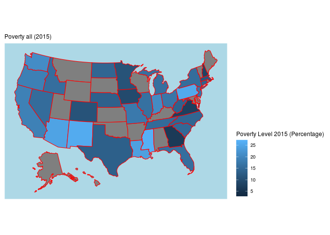

```r
plot_usmap(data = finalmerge, values = "PCTPOVALL_2015", color = "red") +
  scale_fill_continuous(name = "Poverty Level 2015 (Percentage)", label = scales::comma) +
  theme(legend.position = "right")+ labs( subtitle = "Poverty all (2015)") +
  theme(panel.background = element_rect(color = "white", fill = "lightblue"))
```

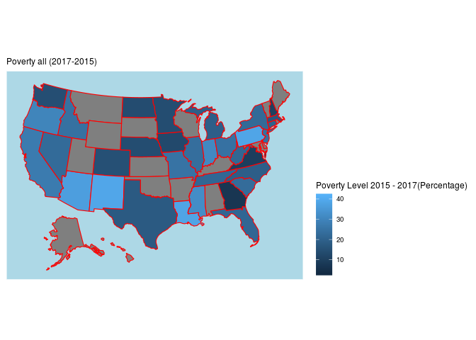

```r
plot_usmap(data = finalmerge, values = "PCTPOV017_2015", color = "red") +
  scale_fill_continuous(name = "Poverty Level 2015 - 2017(Percentage)", label = scales::comma) +
  theme(legend.position = "right")+ labs( subtitle = "Poverty all (2017-2015)") +
  theme(panel.background = element_rect(color = "white", fill = "lightblue"))
```

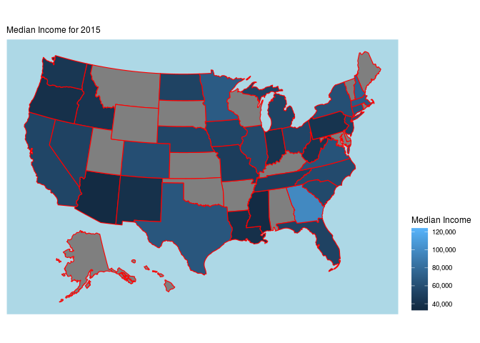

```r
plot_usmap(data = finalmerge, values = "MEDHHINC_2015", color = "red") +
  scale_fill_continuous(name = "Median Income", label = scales::comma) +
  theme(legend.position = "right")+ labs( subtitle = "Median Income for 2015") +
  theme(panel.background = element_rect(color = "white", fill = "lightblue"))
```

> options(scipen) to remove scientific notation. The population year shows similar pattern, thus using gather funtion to make it as one values and ploting in the map (2013-2016).

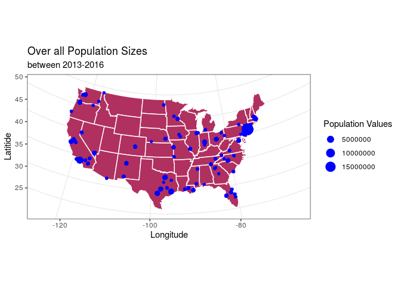

```r
options(scipen=999) #removes the scientific notation

finalmerge %>%
select(latitude.y, longitude.y, POPESTIMATE2013, POPESTIMATE2014,POPESTIMATE2015,POPESTIMATE2016) %>%
gather(key = population, value = numbers, -latitude.y, -longitude.y) -> pop

map_data("state")%>%
ggplot() + geom_polygon(mapping = aes(x=long, y=lat, group = group),color="white", fill="maroon" )+coord_fixed(1.3) + theme_bw() + guides(fill=FALSE) +
  geom_point(data=pop, aes(longitude.y, latitude.y, size = numbers), fill = "red", color = "Blue") + ggtitle("Over all Population Sizes") + xlab("Longitude") + ylab("Latitide") +
labs(subtitle = "between 2013-2016", size="Population Values")+ coord_map(projection = "albers", lat0 = 39, lat1 = 45)+ guides(fill = FALSE)
```

```r
population_all <- finalmerge %>%
  select(latitude.y, longitude.y,state, PCTPOVALL_2015, PCTPOV017_2015) %>%
  gather(key = population, value = numbers, -latitude.y, -longitude.y,-state)
```

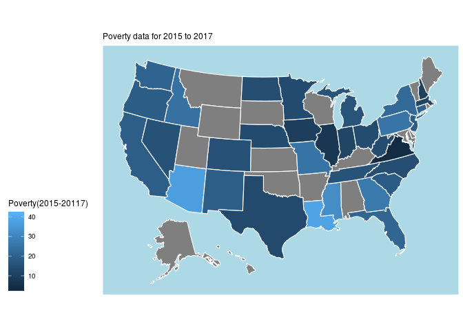

```r
plot_usmap(data = population_all, values = "numbers", color = "white") +
  scale_fill_continuous(name = "Poverty(2015-20117)", label = scales::comma) +
  theme(legend.position = "left") + labs( subtitle = "Poverty data for 2015 to 2017") +
  theme(panel.background = element_rect(color = "white", fill = "lightblue"))
```